# Maths, Systems and Research

*in the Age of AI*

Soma S Dhavala

IIT Jammu · a talk for undergraduates

## Why I am standing here

- You have spent twelve years, maybe more, **solving problems somebody else set for you**
- You were good at it. That is why you are in this room
- Soon — a project, a thesis, a job — somebody will say **“find a problem worth working on”**
- And nobody has ever taught you how to do that

That gap is what today is about. It is not a gap in your ability. It is a gap in what you were asked to practise.

## Three parts, and two questions each

I have been doing research for about twenty years. In that time the ground moved under this profession.

|  | What changed | What did not |
| --- | --- | --- |
| **1 · Research as inquiry** | answers got cheap | **nobody can tell you what to ask** |
| **2 · Systems as the opportunity** | expertise stopped being locked inside people | machines and instruments are still unequal |
| **3 · Maths as foundation** | the **working out** got cheap — the proof, the code, the looking-up | **seeing what to work out** is still earned |

They go in that order for a reason. **A good problem needs a conflict. Conflicts sit at the boundary between systems. And maths is how you cross a boundary.**

Some of you are already carrying a question you cannot get past. **Keep hold of it.** We come back to it at the end.

## If it helps, think of it as a film

[figure not shown]

SHOLAY · 1975

the villain — one thing, pulled two ways

[figure not shown]

DEEWAAR · 1975

the wall — two worlds, each of them right

[figure not shown]

AMAR AKBAR ANTHONY · 1977

the locket — strangers who are brothers

- **Research** — every problem needs a **villain.** “We should improve X” is a wish, and a wish has no plot. Gabbar is not a bad man in the story; **he *is* the story**
- **Systems** — the conflicts worth having sit between **two worlds that are each right on their own terms.** Poor and rich. Law and blood. Duty and family. That line is a boundary, and **boundaries are where the problems are**
- **Maths** — the **recognition scene.** The locket, the birthmark, the song from childhood. Two things you were certain were different turn out to be one

Three films, and the same three parts. **A villain, a wall, and a locket.**

Film posters reproduced for teaching purposes; rights with the respective producers.

## One building in New Jersey

Bell Labs, Murray Hill. Within a few corridors of each other, over about twenty years.

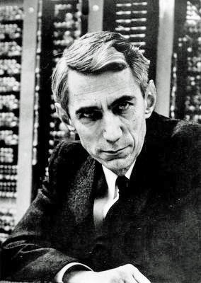

Claude Shannon

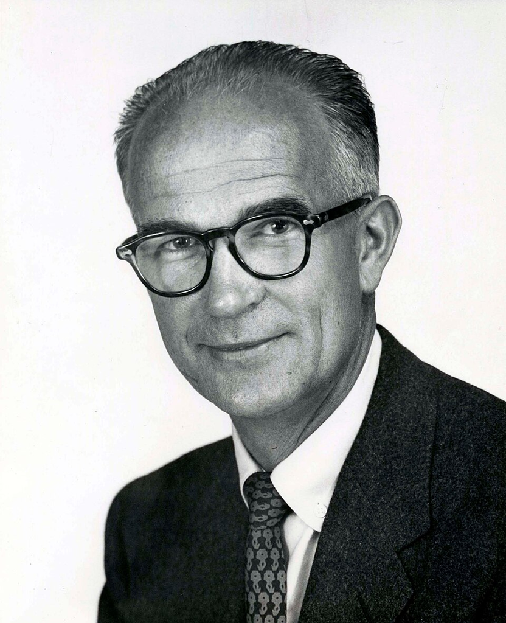

William Shockley

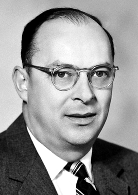

John Bardeen

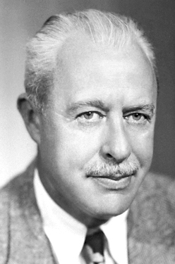

Walter Brattain

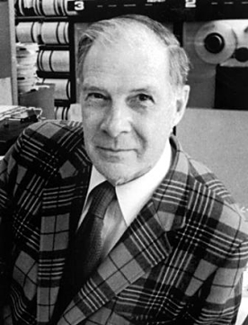

Richard Hamming

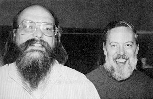

Ritchie & Thompson

[figure not shown]

Brian Kernighan

## And what came out of it

| Who | What | Which gave us |
| --- | --- | --- |
| **Bardeen and Brattain** — then **Shockley** | the point-contact transistor, 1947; the junction transistor soon after | **compute** — every chip since |
| **Claude Shannon** | information theory, 1948 | **information** — what a bit is, and how much you can send |
| **Richard Hamming** | error-correcting codes, 1950 | how to send it and know it arrived intact |
| **Ken Thompson & Dennis Ritchie** | Unix, 1969; C, by Ritchie, 1972 | **programming** — how nearly everything since has been written |

Compute, information, programming. Every model running today rests on those three, and they came out of one building.

## And then the people moved

- Shockley left Bell Labs in 1955 and opened his own laboratory in California in 1956. Eight of his people walked out in 1957 and founded **Fairchild Semiconductor**
- Two of those eight later founded **Intel**
- That is where Silicon Valley begins. In effect, a Bell Labs corridor relocated to California

Which is the point. The knowledge was in the **people**. When the people moved, it moved with them — and if you were not near them, you did not have it.

## What has changed since I was where you are

That is one building, and it is not the only one. Berkeley, Cambridge, the IITs — the same story with different names.

20 years ago knowledge was in books, papers and **people**. Talent and knowledge were concentrated, and the likes of MIT, Harvard, Bell Labs and the IITs were **the place**.

That last word is the one that mattered. If the knowledge sat inside a person, you had to **be near that person**. So everyone tried to get near the same few people.

No longer. Now more than ever, anybody can do good work — except computational or physical infrastructure is the limiting factor. **Access is not the problem.**

Two different things are being called access, and only one of them changed.

- **Knowing** — the books, the papers, what a specialist would tell you. **That is solved**
- **Having** — the cluster, the instrument, the laboratory. **That is not, and it is still unequal**

## Then what is left?

If the books, the papers, the people and the machines are all a question away, the obvious thing to ask is why any of this is still difficult.

- I opened by saying nobody has taught you how to **find a problem worth working on**
- That is still true. And now that everything else has been handed over, **it is most of the job**
- What did not move is knowing **which question is worth asking**

That is a large claim, and you should not take it on my word. So let me put one object on the table.

## A cup of tea, going cold

Not a research paper. Something on your desk.

The same cup can be handed to you as **three completely different tasks** — and you have only ever been given the first one.

the whole talk is about this

## One cup, three questions

|  | What you are asked | Who supplies what |
| --- | --- | --- |
| **The exam question** | Here is Newton's cooling law. Here is the cup at 90 °C. What is the temperature after ten minutes? | **everything** — the formula, the boundary, and what counts as right |
| **The systems question** | Why is it going cold *faster* than the formula said? | **you** decide what to count. The metal table under it? The open surface? The draught? |
| **The research question** | **Can we make a better cup?** | **nothing** — starting with what "better" is even supposed to mean |

the same cup, three times

You have done the first many times. The third is one nobody has asked you.

## The same three, drawn

[figure not shown]

Fig 1 — what is handed to you, and what is not

Your education so far has been the left-hand block. Research is the right-hand one.

## And “better” is not obvious

It sounds like an easy word. Try to pin it down.

- **Keeps the tea hot for longer?** Then you cannot drink it — it arrives at 90 °C and stays there
- **Cools quickly to drinking temperature?** Then it keeps going, and it is cold by the third sip
- So the cup must **cool fast and cool slowly**. Which sounds like nonsense

That sentence, the one that sounds like nonsense, is the research problem. We take it apart in Part one.

## Not every cup is a mug

Kumbakonam coffee does not come in a ceramic mug. It comes in a **davara and tumbler** — thin metal, no handle, and far too hot to pick up.

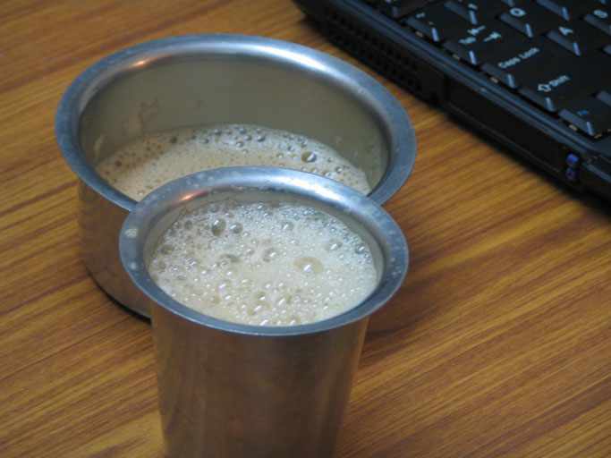

the tumbler sits in the davara

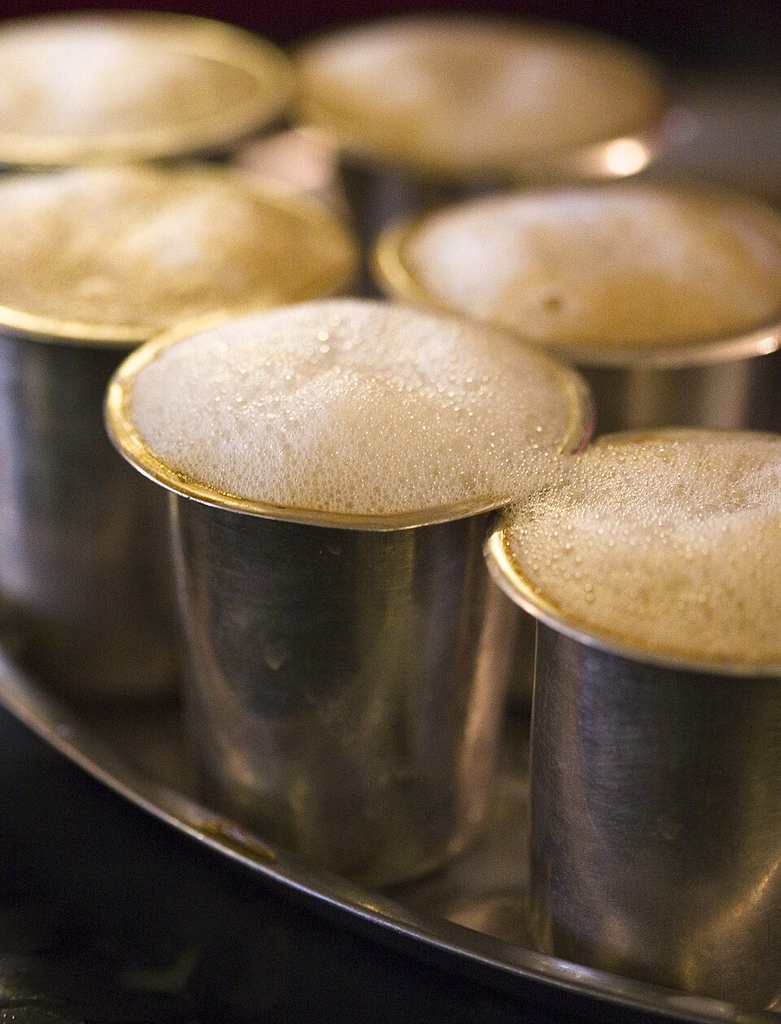

and you pour it, back and forth

## And while we are in Kumbakonam

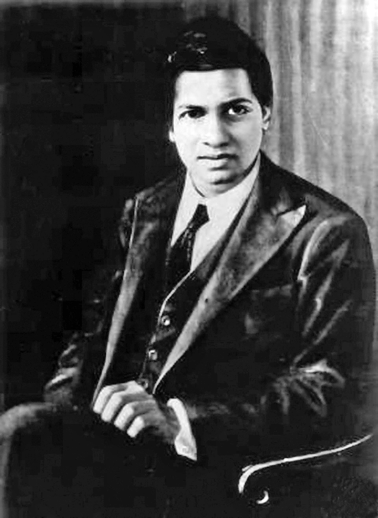

Srinivasa Ramanujan, 1887–1920

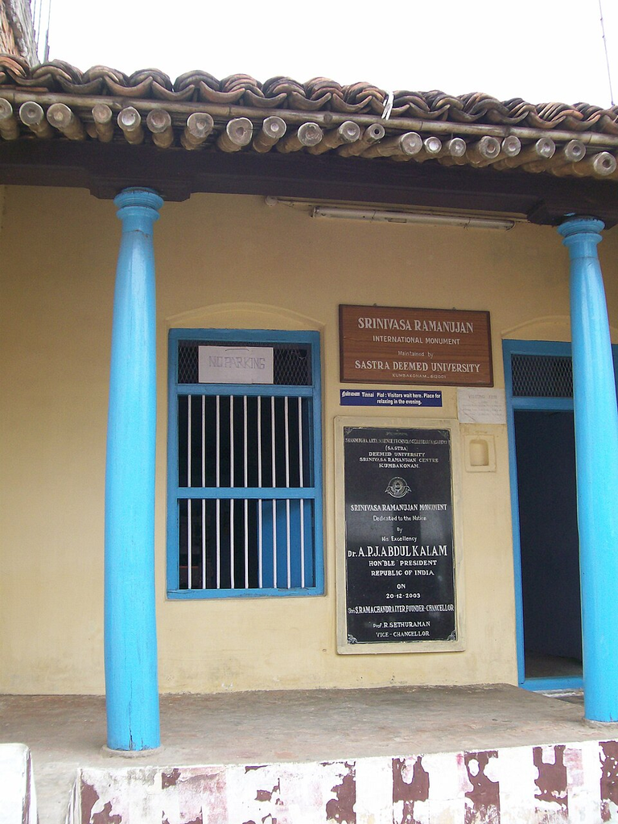

his house, Sarangapani Sannidhi Street

The same town. He grew up a few streets from where that coffee is made, worked mostly alone, out of one borrowed book, and posted his results to Cambridge because there was nobody nearer to send them to.

Hold that thought for Part two, when I tell you what it used to cost to reach somebody who could understand you.

## Now score it the way we just scored the cup

Take the objective a sensible engineer would write down — **lose as little heat as possible** — and mark this vessel against it.

- Thin metal, and metal conducts. **It sheds heat about as fast as anything you could design**
- Then you make that worse deliberately: pouring it into a wide shallow bowl and back, a thin sheet with air on both sides
- And as a thing to hold, it fails plainly. **It scalds your fingers.** You take it by the rim, or you hold the davara instead

Poor on heat retention. Poor on comfort. And in daily use, by millions of people, for as long as anyone can remember.

## So either everyone is wrong

— or the two things we just measured were not what the object is for.

- What it demonstrably **does**: brings very hot coffee down to drinkable in well under a minute, and aerates it on the way
- Whether that is *why* it came to be shaped this way, **I do not know.** I have not seen the history and I am not going to invent it
- But I can say what it is good at, and it is not the thing we scored it on

Both vessels are correct. **A ceramic mug is for a drink you return to over an hour. This is for a drink finished in three minutes.** Neither is a better cup in the abstract, because there is no such thing.

## And one equation, which I am showing you once

∂u/∂t = α∇²u

heat spreads out · that is the entire content

**You do not need to read the symbols.** It says one thing: wherever something is hotter than its neighbours, it leaks into them, until it stops being hotter. Tea into the room. Hot water into cold.

We meet it four more times — in a bathtub, in a city, in a photograph, and in the last picture I show you — and it will not look like itself on any of them.

# Research as inquiry

Part one of three · the part nobody can do for you

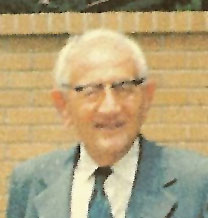

George Pólya  
1887–1985

It is foolish to answer a question that you do not understand.

*How to Solve It*, 1945 — still the best book on the subject

## Two different things

Notice what that sentence separates, because most people run the two together.

- **Understanding** a question — knowing what it claims, what would count as an answer, and what would refute it
- **Answering** it

Only the first is needed to begin. And people give up not when the second one stalls — which is normal, and can last years — but when they discover the first was never done.

A question you understand exactly is one you can put down and pick up again. One you half understand does not survive the week.

## Let me tell you one of my own

The prologue left you one question sitting at an edge — a cup that has to cool fast and cool slowly. Here is a time I noticed one myself, and what happened next.

It is the only story in this talk that runs from the noticing all the way to the end.

## It begins with somebody else’s inequality

There is a small classical fact, and it sits at the end of a chain.

| Year | Who | What they measured | Which distribution it pins down |
| --- | --- | --- | --- |
| 1981 | **Chernoff** | a bound on the variance | — he proved the inequality |
| 1983 | **Borovkov and Utev** | the same bound, and its converse | **the normal** |
| 1991 | **Freimer and Mudholkar** | distance from the **median** | **the Laplace** |
| — | *the one I could not finish* | distance from **any quantile** | the asymmetric Laplace |

Chernoff, *Ann. Probab.* 9 (1981) 533–535. Borovkov & Utev, *Theory Probab. Appl.* 28 (1983) 219–228. Freimer & Mudholkar, “An analogue of the Chernoff–Borovkov–Utev inequality and related characterization”, *Teor. Veroyatnost. i Primenen.* 36(3) (1991) 609–612; SIAM translation, *Theory Probab. Appl.* 36(3), 589–592.

## The paper

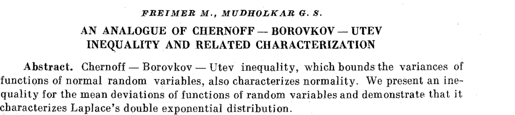

*Teor. Veroyatnost. i Primenen.* **36**(3), 1991, 609–612

- This is the whole thing. **Four pages**, in a Russian journal, in 1991
- **I came across it by accident.** I was not working on this. No question about quantiles, no programme, nothing I was trying to prove. I read it because it was in front of me
- And reading it, I saw an opening straight away

## The opening I saw

Their result is about the **median**. And the median is only one quantile among many.

- People who work with quantiles do not measure distance with $|x|$. They use a lopsided version, the pinball loss
- So: swap the median for **any** quantile, swap absolute distance for the pinball loss
- **The same thing ought to happen** — with the asymmetric Laplace taking the Laplace’s place

I had the intuition. I saw the pattern. I showed it to a few people.

## Which is worth saying plainly

I did not sit down and pose myself this question. **The question came out of reading something I had no business reading**, on a subject I was not working on.

That is what people mean by serendipity, and it is not luck. It is what happens to somebody who reads outside the thing in front of them — and it is the first casualty when you only ever ask for exactly what you need.

## Written down, and stuck

You are not meant to read this. It is here so you can see the size of the thing.

$$\mathrm{AMD}_\kappa[g(X)] \;\le\; \mathbb{E}\big[\eta_\kappa(X)\,|g'(X)|\big]$$

for every absolutely continuous $g$, with equality exactly when $g$ is affine

$$\Longrightarrow\quad X \sim \mathrm{ALD}(\mu,\sigma,\kappa)$$

- The **inequality** — the left-to-right part — I could do
- The **converse**, the arrow above, is the one that matters, and it is the one that stopped me
- **I could not prove it**, and it sat there for years

## And I could not ask anyone either

I showed it to a few people. That is not a figure of speech — **a few people was the entire expertise available to me.**

- Somebody, somewhere, could have closed it in an afternoon. There are people who spend careers on characterisation theorems
- I did not know who they were, they did not know I existed, and there was no corridor between us
- This is the Bell Labs problem again, from the other side. **The knowledge was in people, and I was not near them**

So it sat. Not because it was wrong, and not because it was hard to state. **Because I had run out of both the working out and the people.**

## Then it came unstuck

I used **Claude and Codex as maths co-pilots.** I tried it because I had watched them solve olympiad problems, and thought: if that, then perhaps this.

- It was not one question and one answer. **It took a great many iterations**
- Some of what came back was wrong, and confidently wrong. Deciding which was which was mine to do
- The shape of the work was: propose, read what came back, find where it broke, adjust, again

Predict, be corrected, adjust. I was doing gradient ascent on a proof, with a very fast partner.

## So what actually changed

Two things, and they are the two the story has been about.

- **The working out.** The perturbation argument I could never take on my own — I could finally **try** it, in an afternoon instead of never
- **The asking.** I no longer needed to already know which specialist to find. I could put the question at two in the morning, without being near anybody

And one thing did not change at all.

The guess was mine. The checking was mine. **Only the middle got faster.**

## The same loop, running on my own work

- **Hypothesise.** The median result should carry over to any quantile. I wrote it down and believed it
- **Experiment.** Years later I could finally push on it, with a machine that would not get tired
- **Observe.** It came back with **a counterexample.** One example, and the thing I had written down was false
- **Deduce.** Not a slip. **I had misread how the original proof worked** — and built years on the misreading
- **Loop.** A corrected version, which is true, and proved

Not unproved. **False.** After years of trying to prove it.

## Where it stands

- The first version was **wrong.** One counterexample was enough
- The second version is **right, and proved** — but it answers a smaller question than the one I asked
- The rest is **not closed. It is unexamined** — nobody has tried the one route that is known to work in the simpler case

The result did not answer my question. **It changed which question was worth asking.**

So the working out is cheap and the expert is available. What is the hard part now?

## Finding the problem in the first place

Look at what is left once you take those two away.

- The **working out** — handled
- The **asking** — handled
- **Which question to spend the next two years on** — nobody, and nothing, will tell you

And notice how badly I did at it. My whole story turned on **reading the right four pages by accident.** That is not a method, and you cannot plan around it.

So we need something better than luck: a way to look at a question you are considering and say whether it is worth the years. **There is one, and it takes a single line.**

## What makes a problem good

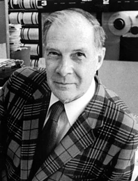

Richard Hamming  
1915–1998

It’s not the consequence that makes a problem important, it is that you have a reasonable attack.

*You and Your Research*, 1986 · *The Art of Doing Science and Engineering*, 1997 · “The Unreasonable Effectiveness of Mathematics”, *American Mathematical Monthly*, 1980

## Which is a relief

An important problem is **not** one with a big payoff. It is one **you have a way into.**

- Time travel would be worth a Nobel Prize, and it is not an important problem, because nobody has a way in
- So you do not have to find something enormous. **You have to find something you can get a grip on**

Inquiry is at the heart of it.

## And “reasonable” is not the same for everybody

Notice who was saying it. Hamming was at Bell Labs, with a computer, a machine shop, a budget, and Shannon down the corridor. **What counted as a reasonable attack for him is not what counts for you.**

- For somebody with a company and a few billion dollars, a reasonable attack on reusable rockets is **to build a rocket company**
- For you, this term, it is something you can get somewhere with using a laptop, a supervisor, and whatever is in this building
- Same test. **Different answer, because the test is about reach, and reach is not equal**

Which is what makes it a useful test rather than a discouraging one. It does not ask you to find something important. It asks you to find **the overlap between what matters and what you can actually get your hands on.**

## And what shape it takes

**A problem will have a conflict in it.**

- **Engineering** is solving the known
- **Science** is dealing with the unknown
- **Research** is converting the unknown into the known

You have seen one already: the cup, which must cool fast *and* cool slowly. **Three more are waiting in Part two**, and every one of them is a conflict nobody had written down.

And as a rule rather than as an exception, that conversion is about **resolving the tension in the conflict.**

## So, a good problem

Three tests, and they go in this order:

1. **It has a conflict** — one thing pulled two ways, each side with a reason
2. **It has a reasonable attack surface** — a way in, at *your* reach
3. **It has a consequence** — somebody is different if you turn out to be right

And notice where test one is easiest to satisfy. **A boundary between two fields is already a conflict** — two ways of doing things, each with a reason, meeting at a line nobody has drawn. **That is where we go next**, and Part two hands you the first test for free.

That is the order you **apply** them in, not the order they matter in. Consequence is checked last because it is the hardest to judge in advance — **last to check, not least to matter.**

## And inquiry is the tool

Three questions, one for each test:

- **Is there a conflict here?** Keep asking until two things you believe turn out to disagree
- **Can I get in?** Not can the field get in — can *you*, with what you have
- **Does it matter?** Who is different if this turns out to be true

You do not find a good problem first and then start asking. **The asking is what turns a topic into a problem.**

## Back to the cup

The conflict we left at the start: the cup must **cool fast and cool slowly**.

- Fast from 90 °C, so you can drink it
- Slowly from 60 °C, so it stays drinkable

One property, temperature. Two opposite demands, each with a reason. **That is the shape.**

still going cold

Put a material in the wall that melts at about 60 °C. Above that it absorbs heat and the tea falls quickly. Below it, the material gives the heat back. The conflict is not split down the middle; it is arranged so both sides get what they asked for.

## Nothing gets invented at this step

Failures are gradient ascent signals.

Hypothesise. Experiment. Observe. Deduce. **Then loop.** Research is that same loop, run over years rather than minutes.

And notice what turning a wish into a conflict actually costs. **Nothing was invented.** The physics did not change, the cup did not change. The only thing that changed is the sentence.

## Persisting, and what separates it from stubbornness

Two things in this talk sat unfinished for a long time.

- **Mine** sat for years, written down and unproved
- And in **Part three** you will meet one that sat for **a hundred and sixty years** before anybody could solve it in general

Neither survived because somebody believed in it hard enough. They survived because each was **stated precisely enough to still be there when the tools arrived.**

When everybody says wrong, if you believe in it, persist.

## Which needs one condition attached

Belief on its own does not separate persistence from stubbornness, and the room always knows the difference.

- Hold on to a **preference** and you are being stubborn
- Hold on to a **structure you can state** — one you could hand to somebody else, that could be shown wrong — and you are being persistent

Perseverance is a trait to be built.

## What has not changed at all

- **Ordinary things lead to extraordinary outcomes.** Not genius. Ordinary things, done a little better, for a long time
- **Curiosity must be cultivated.** It is a habit, and habits are built deliberately
- **Intellectual solitude, but collective working.** Form your own view first, then go and get argued with
- **Learn to be lonely in the pursuit. Embrace ambiguity, imperfection and uncertainty. The more it is, the more the opportunity**

Serendipity — the explore/exploit balance. The need of the hour in AI. And music as a mental reset; it could be any other hobby.

## Where we are

- Part 1 ✓**Research as inquiry.** A good problem has a conflict in it, a way in that is *yours*, and a consequence — checked in that order.
- but →We know **where to look** — at a boundary. We have not yet seen **what is actually sitting there**, or why those problems get left alone.
- Part 2So go and look at four of them.

# Systems as the opportunity gap

Part two of three · where the opening is now

## First, back to the cup

Same cup. Part one named the conflict and resolved it by hand — a material in the wall that melts at about 60 °C.

Now put the research question aside and take the **easy engineering objective** instead — the one almost anybody would write down first.

still the same cup

Just: **lose as little heat as possible.** That is a perfectly respectable engineering problem, and it is the one almost anybody would write down.

## Somebody actually did this

Paras Chopra took that goal, wrote the physics down, added the two constraints that stop it cheating — hold enough tea, mouth wide enough to drink from — and let a program search the shapes.

## The program was not wrong

- It searched honestly. It found **the best answer to the question it was given**
- The shape is genuinely thermally efficient. It resembles a cooling tower because **a tall narrow waist moves a lot of air past a lot of surface** — though a tower is built to *shed* heat and this was asked to *keep* it
- Nobody wrote down **“and a person has to want to hold it”**, so nobody got it

The program did the part that has become cheap. What it left out is what nobody wrote down.

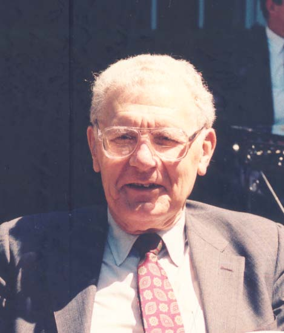

Russell Ackoff  
1919–2009

The righter we do the wrong thing, the wronger we become.

Russell L. Ackoff, operations research and systems thinking  
the formulation recurs across his writing and lectures

## A bath

Before the big examples, one small one — so you can feel the thing happening in your own head. **Commit to an answer before I show you anything.**

You want a bath. Some water is at room temperature. Some you heat. **Which uses less energy?**

|  | Your options |
| --- | --- |
| **1** | Heat a little water, very hot. Add a lot of cold. |
| **2** | Heat a lot of water, gently. Add hardly any cold. |
| **3** | Somewhere in the middle. There is a best split. |

**Hands up.** Count them. Write the numbers on the board before anything else happens.

▶ Open the bath — ask them first, then slide it

## It makes no difference

- 28.6 litres at 90 °C, 50 at 60 °C, 100 at 40 °C — **identical**
- The heat you must put in is fixed by the bath you want, not by how you arrange it
- Slide it as far as you like. The number does not move

There is no best answer, because the question was not well posed.

Idealised throughout: no heat lost while you fill, perfect mixing, and the heater the only thing you pay for. A real bath loses heat to the room, warms the tub itself, and stratifies badly. **None of that changes the point** — it changes where the point stops being true, which is the next slide.

## So what would make it matter?

- Where the water waits, and for how long
- How hot the tank must be so nothing grows in it
- How hot is safe on skin

Now there is a real conflict: the water must be **stored hot** and must **arrive warm**.

And the thing that resolves it is the mixer tap in your bathroom. You have used the answer every day without noticing there was a question.

## An air conditioner

The bath was a wrong question in one room. Here is the same mistake, made by a whole city. It does not destroy heat. It **moves** heat out of your room onto the street — plus everything the motor burns.

| Level | What happens |
| --- | --- |
| Your room | Cooler. Sensible. Nobody is doing anything wrong. |
| The building | Every flat rejecting heat, all day |
| The street | The air outside gets hotter |
| The city | Everyone’s unit works harder — **so the street gets hotter still** |

## Two of them, in a room each

Same two machines. Same two rooms. Same setting on the thermostat. The only thing I am going to change is **where the hot air goes**.

▶ Open the simulation — vented apart, then facing each other

Neither unit is faulty, and neither engineer made a mistake inside their own scope. **Both machines end up shutting themselves down to avoid damage** — the protection working exactly as designed, on a situation nobody designed for.

A deliberately simple model: a fixed fraction of Carnot for efficiency, one lumped temperature for the air at each condenser, and a plain temperature cut-out standing in for a high-pressure trip. Real units have variable-speed compressors, defrost cycles and proper pressure controls. **The feedback is real; the numbers are illustrative.**

## Four levels, and the arrow that comes back

A city that cools itself also heats itself, and no single unit did anything wrong.

## You have already done this

When you last sized an air conditioner in a design class — **did you assume the outside temperature was fixed?**

- Everybody does. It is the sensible engineering assumption
- It is also **a line you drew**
- And you did not notice choosing it

You cannot avoid drawing a line. You can only be aware that you have drawn one.

## Kelvin drew one too

And it is not only students who do this. The most celebrated physicist of his age worked out how old the Earth is, by asking **how long a hot ball takes to cool.**

- His mathematics was faultless
- He got twenty to forty million years, and told the geologists — and Darwin — they were wrong
- The Earth is about **4.5 billion** years old. He was out by more than a hundredfold

## What he calculated

Heat leaving a hot ball, measured at the surface. The arithmetic is correct.

## What Kelvin left out

Not an arithmetic error. What he left outside the problem: the Earth carries heat by **convection** in the mantle, not conduction alone — and, discovered later, it heats itself from within.

## What those four had in common

Not one of them was hard **physics**. Look at what each one actually needed:

| The failure | What it sat between |
| --- | --- |
| **The cup** | thermodynamics + what a person is willing to hold |
| **The bath** | heat + plumbing + what grows in warm water |
| **The city** | heat transfer + how a street is built + what electricity costs |
| **Kelvin** | conduction + geology + a phenomenon not yet discovered |

A component problem sits **inside** one field. A system problem sits **between** several. That is why these were left alone — not because they were deep, but because **no one person could reach across**.

## And reaching across is what I could not do

Years ago I built a method for compressing images. It worked, I published it, and I moved on.

- **Five years later** somebody showed me the CART algorithm — decision trees — and I recognised my own method looking back at me
- Not because it was secret — CART is one of the ten most influential algorithms in data mining
- The structural identity was published too: a 1989 paper had already shown that pruning a classification tree and designing a tree-structured compressor are the same optimisation
- I was in one of those fields. I simply had **no way to find out about the other**

One crossing. **Five years.** That is the price the old arrangement charged, and it is why system problems stayed shut.

## So here is the whole argument

- Deep expertise **inside** one field is now available to anybody — so component-level work is **crowded**
- Reaching **across** several fields is now available to one person — so the thing that made system work hard **stopped being hard**
- And the system problems are still sitting there untouched, because nobody owns them and nobody sees the line

Now that we have access to specialized experts, the innovation frontier moves from the individual to systems. That is where the opportunity is.

## Where the opening is

When the boundary is tight and the environment is constrained because the bar is high — the area is saturated — it is almost as if you have a bottleneck. Any discovery in that space and time must be a breakthrough, and fundamentally refreshing.

- The air conditioner **as a device** is a mature product. The physics is settled, the gains left are incremental, and a great many people are already working on them
- That is not a dead end — **it is the sign**. Everything easy has been taken
- And the street outside has had **nobody working on it at all**

## Where we are

- Part 1 ✓A good problem has **a conflict** in it.
- Part 2 ✓**Conflicts sit at system boundaries.** Every failure we looked at — the cup, the bath, the city, Kelvin — was a line drawn too tightly, not a calculation done badly.
- but →Access gets you to the expert on the other side. **It does not tell you the two sides are the same thing** — and until you see that, there is nothing to go and ask about.
- Part 3So what lets you *recognise* it?

# Maths as foundation

Part three of three · not computing and calculation

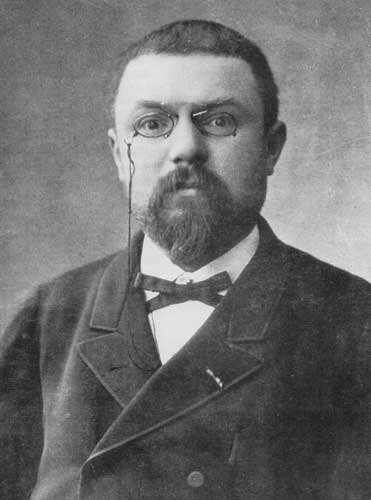

Henri Poincaré  
1854–1912

Mathematics is the art of giving the same name to different things.

*Science et méthode*, Flammarion, 1908  
English: *Science and Method*, tr. Halsted, 1914

## What I mean by foundation

Maths is not computing and calculation. It is structure, abstraction and generalization.

- **Structure** — the same shape turning up in different places
- **Abstraction** — dropping what does not matter
- **Generalization** — solving the whole family, not the one case

Do not be afraid of maths. Now it is accessible.

## How do you find a word in a dictionary?

Start with something you already do without thinking, so we can watch what maths actually *is*. Open the middle. Decide which half. Repeat.

Now — where else have you done exactly that?

- Guessing a number between 1 and 100
- Finding where a graph crosses zero
- Finding which change broke the code
- Floor and ceiling — **the same thing, two characters apart**

## Four questions, and the word is found

Each question throws away half of what is left. That is why it is quick, and it is the same procedure in all four places.

## And it is not as easy as it looks

That move is the simplest useful procedure in computing.

- It was **quietly broken inside Java for nine years** before anyone noticed
- Not because it was hard to write — twelve lines
- Because nobody had said clearly enough **what it was supposed to guarantee**

The arithmetic was wrong in a way the specification never mentioned — and nobody had written down what the routine was supposed to guarantee for a very large array.

The line was `int mid = (low + high) / 2;`. On a very large array `low + high` exceeds the largest number an `int` can hold, wraps around to a negative value, and the lookup fails. The repair is to add half the *gap* rather than halve the *sum*: `low + (high - low) / 2`. Joshua Bloch found it in `java.util.Arrays.binarySearch` in 2006; it had shipped since JDK 1.2. The same error was in his own textbook.

## A problem from 1781

Gaspard Monge, a French military engineer, asked how to move a heap of earth to where you need it for the least total effort. Not the shortest distance — the least **work**, with every shovelful accounted for.

▶ Open the transport plan — move one heap onto another

[figure not shown]

Fig 7 — the 1781 problem, as a bipartite graph

## Which nobody could actually solve

- Monge could state it. He could not solve it in general
- It sat, more or less, for **a hundred and sixty years**
- Then somebody in a completely different subject picked it up again

## And then kept being found again

| Year | Who | What they were doing |
| --- | --- | --- |
| 1942 | **Leonid Kantorovich**, an economist | allocating scarce resources — *and a Nobel Prize for it* |
| 1998 | **Rubner, Tomasi and Guibas** | finding similar photographs |
| 2015 | **Kusner, Sun, Kolkin and Weinberger** | do these two sentences mean the same? |
| 2017 | **Arjovsky, Chintala and Bottou** | training generative models |

Every one of them is Monge’s heap of earth. Someone who knows that holds **one** thing. Someone who met them separately holds **five**.

Monge, *Mémoire sur la théorie des déblais et des remblais*, 1781. Kantorovich, 1942; Nobel Memorial Prize in Economics, 1975. Rubner, Tomasi & Guibas, *A Metric for Distributions with Applications to Image Databases*, ICCV 1998, 59–66; and *The Earth Mover’s Distance as a Metric for Image Retrieval*, *IJCV* 40(2), 2000, 99–121. Kusner, Sun, Kolkin & Weinberger, *From Word Embeddings to Document Distances*, ICML 2015. Arjovsky, Chintala & Bottou, *Wasserstein GAN*, ICML 2017. The distance carries a sixth name too — Wasserstein, after Leonid Vaseršteĭn.

## Which gives you a rule

If the solution is elegant — stripped down to its bare minimum — it is almost always solved earlier.

- Elegance is a sign that **somebody has already been here**, not that you were clever
- So when it gets clean, stop admiring it and **go and look**
- That search used to be expensive. It is not any more

## Twice it happened to me

- **Time-frequency distributions and probability densities.** I noticed the two were the same fitting problem. That is what drew me to statistics
- **My compression method and CART** — the tree from Part two. I did not know. Five years later somebody showed me, and I saw it

Two fields that were not talking to each other. In both cases the structure was the same and the names were different.

This is not a talent so much as a habit, and habits can be practised.

## The first one, side by side

Put a signal’s energy over time and frequency next to a probability spread over two variables and the picture is the same. **Same shape, same edges that have to add up, same problem of fitting one to data.** They are not the same object — one integrates to energy, the other to one, and the time-frequency version can go negative — but the machinery you reach for is.

## The second one

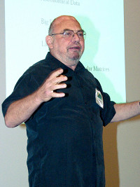

Leo Breiman

1928–2005

**CART**, 1984. Breiman, Friedman, Olshen and Stone. Take your data, split it in two on the best question you can find, then do the same to each half. Keep going until stopping is better than splitting.

**US 7,123,774 B2**, filed 2002. Dhavala and Wheeler. *Initialise a data tree on the bit depth, then split a bin into two bins based on a predicate.*

His tree was built to sort records into classes — the sort of thing used for diagnoses and credit decisions. Mine was compressing images. Neither of us knew about the other.

## Which was which

Three words, and you have now seen one of each.

|  | What it means | The one you just saw |
| --- | --- | --- |
| **Abstraction** | throw away everything that does not matter | **the dictionary.** Not words, not pages, not alphabetical order — only *ordered, halve, compare* |
| **Generalization** | solve the whole family, not the one case | **Monge’s earth.** Not soil and carts — any two heaps, any cost of moving between them |
| **Structure** | the same shape, in two places that never met | **time-frequency and densities. Compression and CART** |

The third is the one that pays immediately. When two things share a structure, **the technique carries across without modification** — you do not adapt it, you just use it.

## None of these are facts

- You cannot look up *this is the same as that*. **Nobody has written that list**, and nobody can
- Abstraction, generalization, structure — all three are things you **notice**, not things you know
- I noticed those two were the same fitting problem long before I could do anything useful with it. **The noticing came first**, and it came from somewhere

So the question is not what to learn. It is **how you get better at noticing** — and that is the only part of this talk that is really about you.

Leon Cohen  
b. 1940

Of course, it is the paradoxes and unusual results that lead to abandonment of ideas, adjustment of our intuition or the discovery of new ideas.

Professor of Physics, Hunter College CUNY  
*Time-Frequency Analysis*, Prentice Hall, 1995 · “Time-frequency distributions — a review”, *Proc. IEEE*, 1989

## How to build intuition

You have already seen this loop once, in Part one, running on a proof. So the pattern-spotting is a habit — fair enough. **How do you get the habit?**

It is not granted. It has to be earned. It will come from failure.

The recipe is — predict, then correct. This is precisely gradient ascent.

## The loop

**Hypothesise. Experiment. Observe. Deduce.** Then loop — and the size of the error tells you which way to move.

## But you have to be able to predict something

The loop has a hole in it. **You cannot make a prediction about a thing you cannot picture** — and most of what you meet in a new subject is exactly that. A definition you can read but cannot see. A theorem stated in words you have to look up.

- So the first move is always the same: **shrink it until you can picture it**
- Take the setting to a limit — zero, one, two, infinity — whatever is simplest but still recognisably the same thing
- **Now** you can guess, and be wrong, and learn something

Here is one I could not picture at all.

## Neural networks can approximate anything

That is the sentence you will hear. **Universal approximation.** Give it any reasonable curve on an interval, and one hidden layer can get as close to it as you like.

## Tool one — extreme cases

Everyone says neural networks can do anything. *Universal approximation.* **I could not picture what that meant.**

- So I pushed it to the simplest case — **what if everything is just 0 or 1?**
- Then it is plain logic. ANDs and ORs you can write on paper
- And once you can see it, **it says far less than people think.** You can cover anything if you are wide enough. It does not say that is a good idea

Same move on the memory of a network. What does it mean to say it remembers? Make it discrete, and you can count it.

## Which gives you a proof, more or less

[figure not shown]

Fig 11 — truth table → sum of products → a network with one hidden layer

## What that argument actually shows

Which is the honest reading of the theorem. It says a wide enough layer can **represent** anything. It says nothing about whether you could ever **find** it, train it, or afford it.

Worked out in full in my own lecture notes — `mlsquare/intro2dl`, Lecture 1, *SOP = MLP with 1-hidden layer*.

## And the rest of the kit

- **Start case by case. Generalize the cases. Start specific, go to general, and come back.** The coming back is the part everybody skips
- **Counter examples.** Go looking for the case that does not fit
- **Debate, self dialogue, inner voice.** When nothing argues back, you have to be your own opponent

No theory without code, no code without theory. Code is practice. Theory is guidance.

## Watch one thing before we leave

Three pictures. Stripes, checks, specks. **Nobody would confuse them.**

Now let each one spread — the same equation, on pixels instead of tea.

▶ Open it — and watch the number, not the pictures

They end up **indistinguishable.** Not similar — you cannot tell which is which.

## Which is what “irreversible” means

- Handed the grey square at the end, **which of the three did it come from?**
- On paper the spreading is one-to-one, so an exact answer exists. **It is of no use to anybody**
- To recover it you would have to measure that square to an accuracy no instrument has. **Any real measurement is consistent with all three**

Hold that. In the last five minutes I am going to show you something running it backwards anyway — and you will need to know why that should be impossible.

## Where we are

- Part 3 ✓**Maths as foundation.** The same structure turns up under different names — and **that is how a boundary gets crossed.** You give both sides the same name, and the technique carries over without modification.
- so →Which is why the working out — the proof, the code, the looking-up — getting cheap matters so much. The crossing that cost me five years is now an afternoon.
- lastOne thing is still hanging: three pictures that spread into the same grey square, with no way back. **Now the thing I told you was impossible.**

## The blurred picture, again

Can we undo it?

- **No.** The detail is gone, and that has been known for a century

▶ Blur it again, and try

So that is the end of it. Except it is not.

## Take one point, and keep nudging it

Not a picture this time. A single point, and at every step you knock it a little, at random.

▶ Open it — watch one point smear out

- After enough steps you have a fuzzy cloud, and **the point is gone**
- That cloud spreads exactly the way heat spreads. The same equation again
- Which is the same problem as the blur: you cannot run it backwards, because you threw the information away

## And yet, backwards

If you cannot undo it, **learn it instead.** Show a machine thousands of examples of a point being nudged, and let it learn which way things came from.

▶ Open the smallest diffusion model there is

Nobody inverted the equation. They **changed the question** — from *undo this* to *learn the way back* — and the second one has an answer.

Both demos are from my own course, `diffusion-models-f26`. This is how **diffusion models** work — noise added on the way in, a learned path back out. It is not the only way to build an image model, but it is the one behind most of the ones you will have used lately.

## And this is what that buys

▶ Open it — run the picture to noise, then noise back to the picture

- Push it right: the image dissolves. **Fine detail first, then everything**
- Push it left: it comes back — and a real model is not replaying a recording, it **computes** each step
- The same thing as the tea, the bath and the city. **Something spreads out, and spreading out is the easy direction**

The equation was never run backwards. **A different question was asked**, and that one had an answer.

Which is what this whole talk has been about. Not answering harder. **Asking something else.**

## One equation

∂u/∂t = α∇²u

the one I showed you once, near the beginning · you have now met it five times

- It cooled your tea
- It gave Kelvin the wrong age of the Earth
- And it produced the picture behind the closing slide

## What the three parts come to

1. **Research — the inquiry**
   - Research is not producing answers. **Research is inquiry** — which comes down to asking good questions
   - A good problem has **a conflict, then a way in that is yours, then a consequence** — checked in that order
   - And that takes **intuition** — seeing what is worth asking before you can prove it
2. **Systems — the opportunity**
   - A component problem sits *inside* one field. A system problem sits *between* several
   - **That boundary is where the tension and the conflict sit naturally** — it hands you the first test for free
   - And they are still sitting there, because no single field owns them and nobody has drawn the line
3. **Maths — the foundation**
   - **Maths is how you cross a boundary.** Give the two sides the same name, and the technique carries over — once you have checked that its assumptions still hold
   - And the intuition to see that is **learnt, not given:** hypothesise, experiment, observe, deduce, loop

Underneath all three: **expertise is accessible now** — the books, the papers, the people, the working out. The *knowing* half, to anybody. **The machines are still unequal.**

## So, four things

**Be curious.** Nobody arrives curious about the right things. It is cultivated, and it is cultivated on purpose.

**Get genuinely good at one subject.** Exploit. Go deep enough in something that you have real judgment about it — you cannot reach across from nowhere.

**Explore the periphery.** Where your subject stops and somebody else’s begins. That is where the questions sit that nobody owns and nobody has drawn a line around. **That question you have been holding since the fourth slide — ask what it touches.**

**Actively pursue gradient ascent over your own knowledge.** Predict. Be wrong. Adjust. Not once, when it happens to you — deliberately, as a habit, for years.

# Go. Climb. *Redefine the boundaries.*